# TURO Investment Tool

### SUMMARY:

Car sharing is a growing industry along with the trending sharing economy. Many factors can affect the profitability of this venture for individual car owners and the main question is to get your car rented 100% days in month. While pricing is obviously a major factor, there are other variables that may affect profitability including car type, location, descriptions, availability settings. The goal of this research is to build a model that will allow owners to predict utilisation rate what cars will be the most profitable in their area, to regulate the prices and understand other factors that will allow them to earn more. This project will be essential for everyone who owns a car that can be rented or everyone who is thinking to start car sharing as a side business.

DATA: The data has been gathered from Turo.com (the leading car sharing web-site/app) and includes information about bookings for the last 12 months). It was gathered through the mix of scraping (BeautifulSoap and Scrapy) and API techniques. Every listing has unique set of parameters (https://turo.com/us/en/car-rental/united-states/los-angeles-ca/toyota/yaris/634022) that we put into a dataframe. It is a structured data frame with the rows as separate listing and columns as variables and outcome value. There are about 70 different variables and around 300,000 listings exist, 100,000 of them were active as of last month and we focused on them. Data types: 1) Numerical: price, year of the car, miles included per booking, delivery prices, prices of the extras, days that car was booked in the previous period during the last 12 months, days unavailable, number of seats, trip count, etc. 2) Categorical: type of the car, type of the fuel, convertible or not, is it a frequently booked or not, any age restrictions, availability, color, etc. 3) Text: listing description, FAQ 4) Geographical: Latitude and Longitude for every listing, State, City, Zip Code

PROJECT STAGES:

1. EDA We are going to clean all numerical variables, windsorize and normalize them. For the categorical variables we will use one hot encoding and for the location we will do unsupervised clustering with k-means and alternative method clustering to see what will work better. We’re going to check the quality of the clusters with the silhouette score. For the text variables we’re going to work with natural language processing algorithms such as parsing, tokenization, bag of words, TD-IDF, word2vec and to add these new variables into our model.  
   We will do feature engineering with psa and umap.
2. MODELING The prediction will be made with supervised learning model such as OLS, Random forest and support vector machine. Outcome variable will be the potential earning per month, in $. We will check the prediction accuracy with cv score through different models.
3. SUMMARY and next steps

CHALLENGE: The primary challenge for this project is to include NLP processing of descriptions. These variables will be added to the categorical and numerical variables with the goal of providing additional guidance for car owners to consider supporting owners in maximizing their profitability. Our expectation is to define an impact which might be hard to reveal. We’re going to overcome this by trying different approaches and use different bag of words sets and techniques from NLP section in order to find out the most efficient set of words or amount of words that helps to earn more money on renting the car.

#### RESULTS

In this project we: 1) reviewed all the available variables that are accessible through public sources for car sharing market, processed them and analysed. 2) were able to cluster them and present top relevant results so potential car owner can evaluate their potential ability in certain areas based on the best performers results. 3) were able to explain the variance of the utilisation rate with these variables and got $30%$ with different models which is low. However, with the OLS model we were able to define postitve and negative influence of the incoming variables, with Random Forest we were able to predict TOP important variables.We think the market itselfe isn't stable enough (owners, company policy) that's why we don't see more reliable numbers from our models. 4) Also, we were trying to see if there are certain words or 2 grams that lead to the higher utilization rate or earnings but unfortunately it is not, the models with these variables doesn't seem reliable more. One of the conclusions that owners should keep their description within 2000 symbols and words such as: $Great$, $Need$, $Time$, $Feature$, $Full tank$, $Airpot Delivery$, $Power$, $Fun$. 5)With Maksov's text modeling we were able to create a text generator trained on the best descriptions based on the utility rate. This is a very useful feature for mew owners.

The area of car sharing is growing and defining the most important factors for increasing the utility rate is very important for car owners. As the next step we would like to continue model development plus would like to develop a tool that will allow owners to generate the text based on the best performed listings

# 1. Basic data exploration

At this stage we will do EDA - check the sanity of the data, make observations on the data type, missing values, outliers, shape of the data.

```python
df.describe()
```

|  | Car ID | Year | Number of seats | Number of doors | GPS | Convertible | Booking Instantly | Latitude | Longitude | Owner ID | ... | Another Occupancy Mar | Another Occupancy Apr | Another Occupancy May | Another Occupancy Jun | Another Occupancy Jul | Another Occupancy Aug | Another Occupancy Sep | Another Occupancy Oct | Another Occupancy Nov | Another Occupancy Dec |
| --- | --- | --- | --- | --- | --- | --- | --- | --- | --- | --- | --- | --- | --- | --- | --- | --- | --- | --- | --- | --- | --- |
| count | 112181.000000 | 112144.000000 | 96156.000000 | 103839.000000 | 50911.0 | 8875.0 | 112144.000000 | 112144.000000 | 112144.000000 | 1.121440e+05 | ... | 19722.000000 | 10203.000000 | 12241.000000 | 13744.000000 | 16021.000000 | 18167.000000 | 18721.000000 | 20031.000000 | 19399.000000 | 22170.000000 |
| mean | 564272.641864 | 2014.471938 | 4.986033 | 3.746126 | 1.0 | 1.0 | 0.119257 | 36.238762 | -92.095995 | 6.530143e+06 | ... | 13.321063 | 9.918063 | 9.846254 | 9.784924 | 10.448911 | 10.498872 | 10.362694 | 11.028656 | 11.241456 | 11.487370 |
| std | 167197.404544 | 4.841130 | 1.105737 | 0.791608 | 0.0 | 0.0 | 0.324093 | 8.282978 | 34.577607 | 4.342536e+06 | ... | 11.099101 | 9.187495 | 9.293097 | 9.010227 | 9.546141 | 9.674732 | 9.651129 | 10.199355 | 10.145531 | 10.224956 |
| min | 92.000000 | 1900.000000 | 0.000000 | 2.000000 | 1.0 | 1.0 | 0.000000 | -45.009944 | -166.541982 | 1.360000e+02 | ... | 1.000000 | 1.000000 | 1.000000 | 1.000000 | 1.000000 | 1.000000 | 1.000000 | 1.000000 | 1.000000 | 1.000000 |
| 25% | 449166.000000 | 2013.000000 | 5.000000 | 4.000000 | 1.0 | 1.0 | 0.000000 | 32.767963 | -117.863654 | 2.496472e+06 | ... | 3.000000 | 3.000000 | 3.000000 | 3.000000 | 3.000000 | 3.000000 | 3.000000 | 3.000000 | 3.000000 | 3.000000 |
| 50% | 611620.000000 | 2015.000000 | 5.000000 | 4.000000 | 1.0 | 1.0 | 0.000000 | 35.318053 | -88.081393 | 6.122656e+06 | ... | 9.000000 | 6.000000 | 6.000000 | 6.000000 | 7.000000 | 7.000000 | 6.000000 | 7.000000 | 7.000000 | 8.000000 |
| 75% | 689721.000000 | 2017.000000 | 5.000000 | 4.000000 | 1.0 | 1.0 | 0.000000 | 41.412861 | -79.743077 | 1.014523e+07 | ... | 23.000000 | 14.000000 | 13.000000 | 14.000000 | 15.000000 | 15.000000 | 15.000000 | 17.000000 | 18.000000 | 17.000000 |
| max | 780059.000000 | 2020.000000 | 15.000000 | 6.000000 | 1.0 | 1.0 | 1.000000 | 71.296937 | 174.893083 | 1.519919e+07 | ... | 31.000000 | 30.000000 | 31.000000 | 30.000000 | 31.000000 | 31.000000 | 30.000000 | 31.000000 | 30.000000 | 31.000000 |

8 rows × 59 columns

```python
df.head()
```

|  | Car ID | URL | Make | Model | Trim | Year | Color | Transmission | Fuel Type | Number of seats | ... | Another Occupancy Apr | Another Occupancy May | Another Occupancy Jun | Another Occupancy Jul | Another Occupancy Aug | Another Occupancy Sep | Another Occupancy Oct | Another Occupancy Nov | Another Occupancy Dec | Processed |
| --- | --- | --- | --- | --- | --- | --- | --- | --- | --- | --- | --- | --- | --- | --- | --- | --- | --- | --- | --- | --- | --- |
| 0 | 92 | https://turo.com/gb/en/car-rental/united-state... | BMW | 3 Series | NaN | 2004.0 | OTHER | A | NaN | NaN | ... | NaN | NaN | NaN | NaN | NaN | NaN | NaN | NaN | NaN | NaN |
| 1 | 279 | https://turo.com/gb/en/car-rental/united-state... | Porsche | 911 | Carrera S | 2006.0 | GRAY | M | Gas | 4.0 | ... | NaN | NaN | NaN | NaN | NaN | NaN | NaN | NaN | NaN | True |
| 2 | 445 | https://turo.com/gb/en/car-rental/united-state... | Toyota | Prius | NaN | 2010.0 | BLUE | A | NaN | NaN | ... | NaN | NaN | NaN | NaN | NaN | NaN | NaN | NaN | NaN | NaN |
| 3 | 724 | https://turo.com/gb/en/car-rental/united-state... | Toyota | Corolla | NaN | 2012.0 | BLACK | A | NaN | NaN | ... | NaN | NaN | NaN | NaN | NaN | NaN | NaN | NaN | NaN | NaN |
| 4 | 972 | https://turo.com/gb/en/car-rental/united-state... | Infiniti | M35 | Sport | 2006.0 | BLACK | A | Gas | 5.0 | ... | NaN | NaN | NaN | NaN | NaN | NaN | NaN | NaN | NaN | NaN |

5 rows × 81 columns

```python
df.info()
```

```
<class 'pandas.core.frame.DataFrame'>
RangeIndex: 112181 entries, 0 to 112180
Data columns (total 81 columns):
 #   Column                               Non-Null Count   Dtype
---  ------                               --------------   -----
 0   Car ID                               112181 non-null  int64
 1   URL                                  112144 non-null  object
 2   Make                                 112144 non-null  object
 3   Model                                112144 non-null  object
 4   Trim                                 72293 non-null   object
 5   Year                                 112144 non-null  float64
 6   Color                                55953 non-null   object
 7   Transmission                         112144 non-null  object
 8   Fuel Type                            103815 non-null  object
 9   Number of seats                      96156 non-null   float64
```

[output cut: 73 more lines]

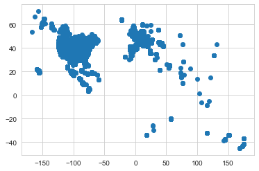

```python
#mapping our location distribution
import matplotlib.pyplot as plt
plt.scatter(x=df['Longitude'], y=df['Latitude'])
plt.show()
```

Turo platform is active around the globe but most of the listings are located in the USA

```python
df.groupby('Country').size().sort_values(ascending=False).head(10)
```

```
Country
US    95264
CA     9269
GB     3160
DE     1398
ES      486
MX      322
FR      254
AE      177
NL      159
IT      150
dtype: int64
```

## 1.2. MODEL Assumptions

We can assume that the next variables might affects target variable but we also will check later if any of them are relevant:

Car characteristics: (I would like to create clusters from these variables after I'll do EDA part

- Type
- Make
- Model
- Color
- Price per day
- Trim
- Transmission
- Fuel type
- Number of seat
- Number of doors
- Year
- GPS
- Convertible

Location

- Latitude
- Longtitude (location clusters with k-means or hierarh)

Owner Performance

- Owner rate
- 5 star hosts

Behavioral

- Booking instantly
- Delivery fees
- Miles included
- Airoport delivery

Text

- Description
- Guidelines

  Text mining options: 1) variable that have amount of symbols 2) bag of words model 3) td-idf

Extras that can affect:

- highValueVehicle
- minimumAgeInYearsToRent
- Registration date
- Trip Count
- Vehicle protection

## TARGET VARIABLE

In this chapter we will define our target variable and drop all listing that doesn't have any booking in 3 previous months

```python
df['Ut_Feb'] = (df['Occupancy Feb ']+1-df['Another Occupancy Feb'])/(29-df['Another Occupancy Feb'])
df['Ut_Feb'] = np.clip(df['Ut_Feb'], a_max=1, a_min=0)
df['Ut_Jan'] = (df['Occupancy Jan']+2-df['Another Occupancy Jan'])/(31-df['Another Occupancy Jan'])
df['Ut_Jan'] = np.clip(df['Ut_Jan'], a_max=1, a_min=0)
df['Ut_Dec'] = (df['Occupancy Dec']+2-df['Another Occupancy Dec'])/(31-df['Another Occupancy Dec'])
df['Ut_Dec'] = np.clip(df['Ut_Dec'], a_max=1, a_min=0)
```

```python
col = df.loc[: , "Ut_Feb":"Ut_Dec"]
df['Ut_R'] = col.mean(axis=1)
```

```python
#drop all emply rows since we won't be able to use them
df = df.dropna(subset=['Ut_R'])
```

```python
#Let's decrease the amount of variables to work with (we're not going to use booking results anymore from previous months)
df = df[['Car ID', 'Year', 'Number of seats', 'Number of doors', 'GPS',
       'Convertible', 'Booking Instantly ', 'Latitude', 'Longitude',
       'Owner ID', 'Price per day',
       'Distance Included/day, Miles, KM', 'Distance Included/Week, Miles, KM',
       'Distance Included/Monthy, Miles, KM', 'Booking Discount - Weekly',
       'Booking Discount - Monthly', 'Fee for extra mile, $', 'Trip Count',
       'Reviews number', 'Owner rate',
       'numberOfFaqs', 'minimumAgeInYearsToRent',
       'numberOfFavorites', 'highValueVehicle', 'allStarHost', 'Ut_R', 'URL',
    'Make', 'Model', 'Trim', 'Color', 'Transmission', 'Fuel Type',
       'Status', 'City', 'State', 'ZIP Code', 'Country', 'Owner',
       'Custom Delivery fee', 'Registration date', 'Vehicle protection',
       'Type', 'Description', 'Guidelines']]
```

# EDA_Variables

```python
#Let's split all the variables into 'nimerical' and 'categorical'
non_numeric_columns = df.select_dtypes(['object']).columns
print(non_numeric_columns)
print("The number of non-numerical columns is {}".format(len(non_numeric_columns)))
```

```
Index(['highValueVehicle', 'allStarHost', 'URL', 'Make', 'Model', 'Trim',
       'Color', 'Transmission', 'Fuel Type', 'Status', 'City', 'State',
       'ZIP Code', 'Country', 'Owner', 'Custom Delivery fee',
       'Registration date', 'Vehicle protection', 'Type', 'Description',
       'Guidelines'],
      dtype='object')
The number of non-numerical columns is 21
```

```python
numeric_columns = df.select_dtypes(['int64', 'float64']).columns
print(numeric_columns)
print("The number of numerical columns is {}".format(len(numeric_columns)))
```

```
Index(['Car ID', 'Year', 'Number of seats', 'Number of doors', 'GPS',
       'Convertible', 'Booking Instantly ', 'Latitude', 'Longitude',
       'Owner ID', 'Price per day', 'Distance Included/day, Miles, KM',
       'Distance Included/Week, Miles, KM',
       'Distance Included/Monthy, Miles, KM', 'Booking Discount - Weekly',
       'Booking Discount - Monthly', 'Fee for extra mile, $', 'Trip Count',
       'Reviews number', 'Owner rate', 'numberOfFaqs',
       'minimumAgeInYearsToRent', 'numberOfFavorites', 'Ut_R'],
      dtype='object')
The number of numerical columns is 24
```

Transform some of the variable into numerical

#### High Value Vahicle (0/1)

```python
df['highValueVehicle'].unique()
```

```
array([False, True], dtype=object)
```

```python
df['highValueVehicle'] = (df['highValueVehicle'] == True ).astype(int)
```

```python
df['Car ID'].groupby(df['highValueVehicle']).count()
```

```
highValueVehicle
0    5217
1     467
Name: Car ID, dtype: int64
```

#### All Star Host (Y/N)

```python
df['allStarHost'].unique()
```

```
array([False, True], dtype=object)
```

```python
df['allStarHost'] = (df['allStarHost'] == True ).astype(int)
```

#### Delivery fee

```python
df['Custom Delivery fee'].unique ()
```

```
array(['US$40', nan, 'US$20', 'US$15', 'US$30', 'US$50', 'Free', 'US$100',
       'US$60', 'US$65', 'US$10', 'US$5', 'US$45', 'US$70', 'US$80',
       'CA$20', 'US$35', 'CA$40', 'US$120', 'US$85', 'US$95', 'US$75',
       'CA$60', 'US$55', '£60', 'US$90', 'US$25', 'CA$30', 'CA$10',
       'CA$70', '£90', 'CA$25', '120', 'CA$80', '50', '30', 'CA$120',
       'US$110', 'CA$50', 'CA$100', '10', 'CA$65', 'US$105', 'CA$85',
       'CA$90', '£30', '20', '£40', '£50', '£100', '25', '£5', '5', '£20',
       '£10', 'CA$75', '90', 'CA$35', '40', 'CA$45', '£120', '£75', '£15',
       '£25', '100', '80', 'CA$15', 'CA$55', 'US$115', '95', '£70', '£95',
       '45', 'CA$5', '£55', '15', '£35'], dtype=object)
```

```python
#Clean and transform into int
import pandas as pd
def remove_whitespace(x):
    try:
        # remove spaces inside and outside of string
        x = "".join(x.split())
    except:
        pass
    return x
df['Custom Delivery fee'] = df['Custom Delivery fee'].apply(remove_whitespace)
df['Custom Delivery fee'] = df['Custom Delivery fee'].astype(str)
df['Custom Delivery fee'] = df['Custom Delivery fee'].apply(lambda x: x.replace ('CA', ''))
df['Custom Delivery fee'] = df['Custom Delivery fee'].apply(lambda x: x.replace ('US', ''))
df['Custom Delivery fee'] = df['Custom Delivery fee'].apply(lambda x: x.replace ('$', ''))
df['Custom Delivery fee'] = df['Custom Delivery fee'].apply(lambda x: x.replace ('£', ''))
df['Custom Delivery fee'] = df['Custom Delivery fee'].apply(lambda x: x.replace ('₴', ''))
df['Custom Delivery fee'] = df['Custom Delivery fee'].apply(lambda x: x.replace ('р.', ''))
df['Custom Delivery fee'] = df['Custom Delivery fee'].apply(lambda x: x.replace ('Free', '2'))
df['Custom Delivery fee'] = df['Custom Delivery fee'].fillna(0)
```

Create Categories for the delivery -

1 - don't do delivery

3 - paid delivery from 1-50

4 - paid delivery from 51-120

```python
def cat_delivery (del_cost):
    if del_cost == 0:
        return 1
    if del_cost == 1:
        return 2
    if del_cost<50:
        return 3
    else:
        return 4
df['Custom Delivery fee'] = df['Custom Delivery fee'].astype(float)
df['Custom Delivery fee'] = df['Custom Delivery fee'].apply(cat_delivery)
```

#### Make&Model Cleanup

```python
#adjust some text errors
df.Model = df.Model.str.lower()
df.Make = df.Make.str.lower()
```

```python
df.Make.unique()
```

```
array(['jeep', 'honda', 'bmw', 'toyota', 'volvo', 'acura', 'audi',
       'lexus', 'scion', 'chevrolet', 'cadillac', 'ford', 'kia', 'tesla',
       'mazda', 'mini', 'dodge', 'smart', 'infiniti', 'nissan', 'lincoln',
       'hyundai', 'mercedes-benz', 'subaru', 'jaguar', 'volkswagen',
       'fiat', 'porsche', 'maserati', 'chrysler', 'land rover', 'bentley',
       'gmc', 'mitsubishi', 'ferrari', 'mercury', 'lamborghini',
       'delorean', 'pontiac', 'rolls royce', 'saab', 'vw', 'polaris',
       'buick', 'vanderhall', 'saturn', 'suzuki', 'ram', 'renault',
       'dacia', 'vauxhall', 'karma', 'alfa romeo', 'peugeot', 'citroen',
       'seat', 'lotus', 'alfa-romeo', 'skoda', 'aston martin', 'opel',
       'mini (bmw)', 'abarth', 'mclaren', 'hummer', 'ssangyong'],
      dtype=object)
```

```python
df.Model.unique()
```

```
array(['cherokee', 'civic', '5 series', 'prius', 's40', 'tsx', 'cr-v',
       'patriot', 'a3', 'gx 470', 'fit', 'xb', 'camry', 'cruze',
       'escalade esv', 'fusion', 'forte', 'prius c', 'wrangler',
       'model s', 'cx-9', 'avalon hybrid', 'cooper', 'grand caravan',
       'fortwo', 'odyssey', 'sienna', 'insight', 'focus', 'ct 200h',
       'qx60', 'frontier', 'corolla', 'mkz', 'sonata hybrid', 'm-class',
       'a5', 'mx-5 miata', 'elantra', 'outback', 'mazda3', 'volt',
       'titan', 'iq', 'f-pace', 'fiesta', 'silverado 1500', 'soul', 'rio',
       'suburban', 'tacoma', 'grand cherokee', 'gl-class', 's60', '6',
       'altima', 'passat', '500', 'e-class', 'gla-class', 'rav4',
       'accord', 'nx 200t', 'f-150', 'model x', 'silverado 1500 hybrid',
       'macan', 'fusion hybrid', 'expedition', 'c-class', 'pilot',
       'sportage', 'jetta', 'juke', 'ghibli', 'challenger', 'accent',
       'pacifica', 'optima', 'renegade', 'leaf', 'escape hybrid',
       'is 250', 'rogue', 'highlander', 'quattroporte', 'g-class',
       'range rover', '6 series', 'panamera', 'levante', 'escalade',
       'continental gt', '500e', 'corvette stingray', 'boxster', 'versa',
       'golf sportwagen', '911', 'q7', 'cla-class', 'malibu', 'q5', 'z4',
       'lr4', 'm3', 'cayenne', 'mustang', 'range rover sport', 'tucson',
       'cooper coupe', 's-class', '3 series', 'es 350', 's5', 'yaris',
       'a4', 'escape', 'es 330', 'veloster', 'gs 350', 'q3', 'yukon xl',
       'xts', 'sonic', 'outlander sport', 'atlas', 'csx', '1 series',
       '4 series', '488 gtb', 'cobalt', 'wrx', 'tahoe',
       'town and country', '124 spider', 'beetle convertible', 'milan',
       'crosstrek', 'prius plug-in', 'continental', 'camaro', 'impreza',
       '718 boxster', 'maxima', 'corvette', 'elantra touring', 'huracan',
       'camry hybrid', 'dart', 'santa fe sport', 'lr3', 'x1', 'srx',
       'santa fe', 'rav4 hybrid', 'model 3', 'qx50', '200', 'spark',
       'fj cruiser', 'journey', 'cx-5', 'cls-class', '7 series',
       'pathfinder', 'dmc-12', 'g6', 'rx 400h', 'versa note', 'compass',
       'ghost', 'xc90', 'quest', '4runner', 'hr-v', '5-sep', 'ridgeline',
       'forester', 'slk-class', 'tundra', 'x5', 's4', '5', 'explorer',
       'wrangler jk', 'q60 coupe', 'c-hr', 'tc', 'manx', 'golf vi',
       'avenger', 'convertible', 'element', 'q50', 'up', 'rx 350',
       'outlander phev', 'slingshot', 'tiguan', 'mdx', 'caliber',
       'encore', 'taurus', 'venice', 'sky', 'charger',
       'highlander hybrid', 'terrain', 'yukon', 'bolt ev', '718 cayman',
       'm4', 'ia', 'cts', 'armada', 'golf',
       't5/shuttle/caravelle/multivan', 'rogue sport', 'cayman', 'sx4',
       'jx', 'aygo', 'nv200', 'sierra 1500', 'gallardo', '1500',
```

[output cut: 48 more lines]

```
       'insignia sports tourer', 'v8 vantage', 'zoe', 'nx 300',
       '458 italia', 'transit-350 wagon', 'dawn', 'k5', 'gx 460',
       'f-350 super duty', '3-sep', 'ram 3500', 'yaris ia', 'c4', 'q2',
       'adam', 'santa fe xl', 'lx 570', 'ilx', '107', 'pacifica hybrid',
       'ls 460', 'silverado 1500 ld', 'ecosport', 'viano', 'eos',
       'splash', 'tiida', 'premacy', 'blazer', '356 speedster replica',
       'rs 3', 'scout', 'baleno', '5008', 'explorer sport trac', 'hiace',
       'nv 3500 van', 'nv3500 hd', 'savana', 'focus rs', 'x7',
       'california', 'vito', 'partner', 'avalanche', 'avalon', 'nx 300h',
       'clubman', '8-series', 'portofino', 'mirage', 'is 200t',
       'mx-5 miata rf', 'captur', 'corolla hatchback', 'supra', 'x5 m',
       'cruze limited', 'insignia', 'envision', 'nitro', 'touareg 2',
       '2008 crossover', 'cts coupe', '570s', 'azera', 'pt cruiser',
       'captiva sport', 'h3', 'tt coupe', 'korando', 's90', 'aveo', 'rcz',
       '308', 'palisade', 'murano crosscabriolet'], dtype=object)
```

#### Year Categories

```python
def cat_year (year_pr):
    if year_pr < 1990:
        return 1
    if year_pr < 2000:
        return 2
    if year_pr<2016:
        return 3
    else:
        return 4
```

```python
df['YearCat'] = df['Year'].apply(cat_year)
```

#### Distance Included

```python
df['Distance Included/day, Miles, KM'] = df['Distance Included/day, Miles, KM'].fillna(10000)
df['Distance Included/Week, Miles, KM'] = df['Distance Included/Week, Miles, KM'].fillna(10000)
df['Distance Included/Monthy, Miles, KM'] = df['Distance Included/Monthy, Miles, KM'].fillna(10000)
```

#### Non-numerical variables

```
([0, 1, 2, 3], <a list of 4 Text xticklabel objects>)
```

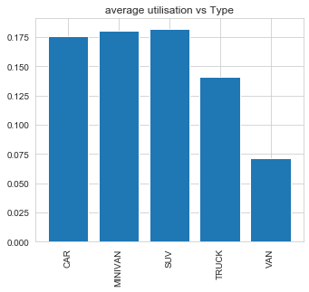

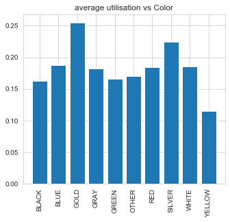

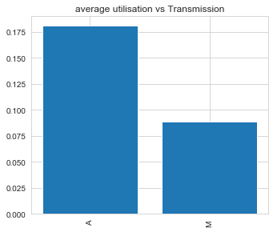

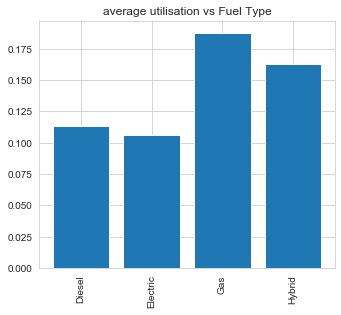

```python
#Let's plot the non-numerical features to check if the variance of the outcome variable is different
plt.figure(figsize=(18, 10))
plt.subplot(2, 3, 1)
plt.bar(df.groupby("Type")
        ["Ut_R"].mean().index, df.groupby("Type")["Ut_R"].mean())
plt.title("average utilisation vs Type")
plt.xticks(rotation="vertical")

plt.figure(figsize=(18, 10))
plt.subplot(2, 3, 1)
plt.bar(df.groupby("Color")
        ["Ut_R"].mean().index, df.groupby("Color")["Ut_R"].mean())
plt.title("average utilisation vs Color")
plt.xticks(rotation="vertical")

plt.figure(figsize=(18, 10))
plt.subplot(2, 3, 1)
plt.bar(df.groupby("Transmission")
        ["Ut_R"].mean().index, df.groupby("Transmission")["Ut_R"].mean())
plt.title("average utilisation vs Transmission")
plt.xticks(rotation="vertical")

plt.figure(figsize=(18, 10))
plt.subplot(2, 3, 1)
plt.bar(df.groupby("Fuel Type")
        ["Ut_R"].mean().index, df.groupby("Fuel Type")["Ut_R"].mean())
plt.title("average utilisation vs Fuel Type")
plt.xticks(rotation="vertical")
```

Seems like we have some correlation between these variables so definetely will include them in the modeling stage

### Cleaning missing variables

```python
total_missing = df.isnull().sum().sort_values(ascending=False)
percent_missing = (df.isnull().sum()/df.isnull().count()).sort_values(ascending=False)
missing_data = pd.concat([total_missing, percent_missing], axis=1, keys=['Total', 'Percent'])
missing_data.head (50)
```

|  | Total | Percent |
| --- | --- | --- |
| Convertible | 5157 | 0.907284 |
| GPS | 3201 | 0.563160 |
| minimumAgeInYearsToRent | 2898 | 0.509852 |
| Guidelines | 2304 | 0.405348 |
| Trim | 1663 | 0.292576 |
| Color | 1657 | 0.291520 |
| Number of seats | 366 | 0.064391 |
| Owner rate | 310 | 0.054539 |
| Description | 268 | 0.047150 |
| ZIP Code | 120 | 0.021112 |
| Number of doors | 114 | 0.020056 |
| Fuel Type | 107 | 0.018825 |
| Owner ID | 0 | 0.000000 |
| Reviews number | 0 | 0.000000 |
| Price per day | 0 | 0.000000 |
| Longitude | 0 | 0.000000 |
| Latitude | 0 | 0.000000 |
| Distance Included/day, Miles, KM | 0 | 0.000000 |
| Distance Included/Week, Miles, KM | 0 | 0.000000 |
| Distance Included/Monthy, Miles, KM | 0 | 0.000000 |
| Booking Discount - Weekly | 0 | 0.000000 |
| Booking Discount - Monthly | 0 | 0.000000 |
| Fee for extra mile, $ | 0 | 0.000000 |
| Booking Instantly | 0 | 0.000000 |
| Year | 0 | 0.000000 |
| Trip Count | 0 | 0.000000 |
| YearCat | 0 | 0.000000 |
| numberOfFavorites | 0 | 0.000000 |
| numberOfFaqs | 0 | 0.000000 |
| highValueVehicle | 0 | 0.000000 |
| Type | 0 | 0.000000 |
| Vehicle protection | 0 | 0.000000 |
| Registration date | 0 | 0.000000 |
| Custom Delivery fee | 0 | 0.000000 |
| Owner | 0 | 0.000000 |
| Country | 0 | 0.000000 |
| State | 0 | 0.000000 |
| City | 0 | 0.000000 |
| Status | 0 | 0.000000 |
| Transmission | 0 | 0.000000 |
| Model | 0 | 0.000000 |
| Make | 0 | 0.000000 |
| URL | 0 | 0.000000 |
| Ut_R | 0 | 0.000000 |
| allStarHost | 0 | 0.000000 |
| Car ID | 0 | 0.000000 |

We have only 10% cars here a convertible and missing values mean 0 and some other variables empty because owner didn't feel it. It's better not to use replace missing values by 0

After dropping the unsignificant colums we will replace all the missing values with 0 since this is what this is mean

```python
#Dropping all the listings without bookings and without any trips.
df = df.fillna(0)
df = df[df['Ut_R']>0]
df = df[df['Trip Count']>0]
```

## OUTLIERS

There are only two variables that are not limited and potentially can have outliers. "Price per day" and "Fee for extra mile". Let's check them

Let's check some variables that can have outliers. Hue will be "High value vehicle" since the prices can be significantly different

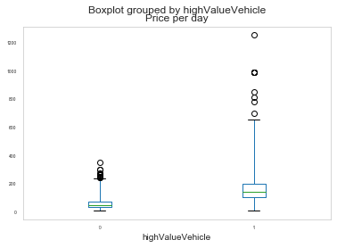

```python
boxplot = df.boxplot(column=['Price per day'], by='highValueVehicle',
                     return_type=None, grid=False, rot=5, fontsize=5, whis=5)
```

```python
from scipy.stats import mstats

def winsorize_series(group):
    return mstats.winsorize(group, limits=[0,0.05])

groupby_price = df.groupby('highValueVehicle')
```

```python
df['Price per day_w'] = groupby_price['Price per day'].transform(winsorize_series)
```

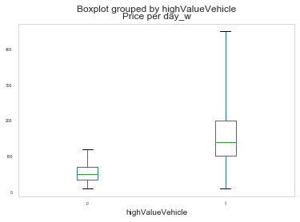

```python
boxplot = df.boxplot(column=['Price per day_w'], by='highValueVehicle',
                     return_type=None, grid=False, rot=5, fontsize=5, whis=5)
```

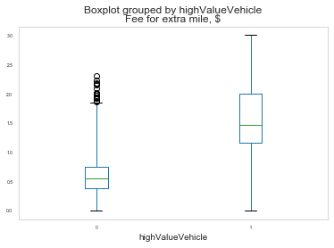

```python
boxplot = df.boxplot(column=['Fee for extra mile, $'], by='highValueVehicle',
                     return_type=None, grid=False, rot=5, fontsize=5, whis=3)
```

```python
df['Fee for extra mile, $'] = groupby_price['Fee for extra mile, $'].transform(winsorize_series)
```

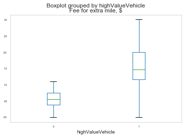

```python
boxplot = df.boxplot(column=['Fee for extra mile, $'], by='highValueVehicle',
                     return_type=None, grid=False, rot=5, fontsize=5, whis=3)
```

Seems all compact now without outliers

### Correlation between numerical variables

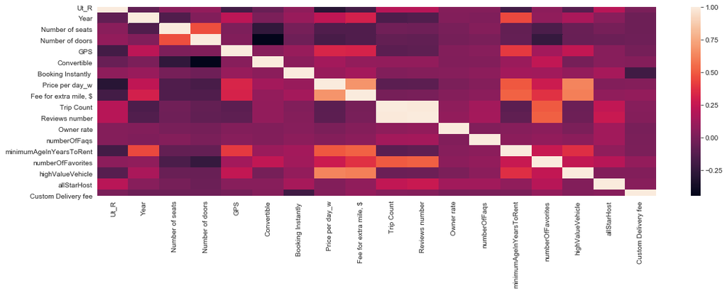

```python
# make the correlation matrices.

plt.figure(figsize=(18,5))

sns.heatmap(corr_df.corr())
plt.show()
```

We'll focus on the variables that are most correlated with the Utilisation rate

```python
np.abs(df.iloc[:,1:].corr().loc[:,"Ut_R"]).sort_values(ascending=False)
```

```
Ut_R                                   1.000000
Price per day_w                        0.291244
Price per day                          0.254128
allStarHost                            0.211369
Reviews number                         0.209465
Trip Count                             0.204776
Longitude                              0.201085
minimumAgeInYearsToRent                0.189081
Fee for extra mile, $                  0.188515
GPS                                    0.187771
Latitude                               0.152291
highValueVehicle                       0.121117
Owner ID                               0.112557
Booking Discount - Monthly             0.092456
Booking Discount - Weekly              0.089025
Distance Included/day, Miles, KM       0.087496
Number of doors                        0.084353
Year                                   0.083427
Distance Included/Week, Miles, KM      0.078182
YearCat                                0.072390
Distance Included/Monthy, Miles, KM    0.071726
Booking Instantly                      0.070529
numberOfFavorites                      0.066473
Convertible                            0.057415
Number of seats                        0.051947
Owner rate                             0.040005
numberOfFaqs                           0.039431
Custom Delivery fee                    0.005721
Name: Ut_R, dtype: float64
```